# Cars Consumption Analysis

Pedro A. Alonso Baigorri

## 1 - Executive Summary

The purpose of this analysis is exploring the relationship between a set of variables and miles per gallon (MPG) (outcome) in the mtcars dataset included in R Studio. On this sense the objective is to answer the following two questions:

- “Is an automatic or manual transmission better for MPG”
- “Quantify the MPG difference between automatic and manual transmissions”

Regression Modelling techniques are used to perform this analysis.

## 2 - Exploratory Data Analysis

With the following r Code I can see the main variables of the dataset.

```r
data(mtcars)
head(mtcars, 1)
```

```
##           mpg cyl disp  hp drat   wt  qsec vs am gear carb
## Mazda RX4  21   6  160 110  3.9 2.62 16.46  0  1    4    4
```

The outcome of this analysis is the variable mtcars$mpg (Miles per Gallon). Higher values of this variable means lower fuel consumption.

In the annex can be found a plot showing that there is a main dependence of the consumption depending on the transmission type. Cars with automatic transmission in general consumes more than manual transmission. Other plots with the analysis of the rest of variables can be found also in the annex.

## 3 - Model selection

Now I wil fit a regression model to quantify the impact of Transmission in the consumption but linked also with the rest of the variables. First of all I’ll try a single model using only am as a regressor since it’s thekey variable for this analysis

```r
fit0 <- lm(mpg ~ factor(am), data = mtcars)
summary(fit0)$coefficients
```

```
##              Estimate Std. Error   t value     Pr(>|t|)
## (Intercept) 17.147368   1.124603 15.247492 1.133983e-15
## factor(am)1  7.244939   1.764422  4.106127 2.850207e-04
```

```r
summary(fit0)$r.squared
```

```
## [1] 0.3597989
```

```r
cor(mtcars)[-1, 1]
```

```
##        cyl       disp         hp       drat         wt       qsec
## -0.8521620 -0.8475514 -0.7761684  0.6811719 -0.8676594  0.4186840
##         vs         am       gear       carb
##  0.6640389  0.5998324  0.4802848 -0.5509251
```

```r
fit0 <- lm(mpg ~ factor(am), data = mtcars)
fit1 <- lm(mpg ~ factor(am) + cyl + disp + wt + hp, data = mtcars)
fit2 <- lm(mpg ~ factor(am) + cyl + disp + wt + drat + vs + carb, data = mtcars)
anova(fit0, fit1, fit2)
```

```
## Analysis of Variance Table
##
## Model 1: mpg ~ factor(am)
## Model 2: mpg ~ factor(am) + cyl + disp + wt + hp
## Model 3: mpg ~ factor(am) + cyl + disp + wt + drat + vs + carb
##   Res.Df    RSS Df Sum of Sq      F    Pr(>F)
## 1     30 720.90
## 2     26 163.12  4    557.78 20.222 2.112e-07 ***
## 3     24 165.50  2     -2.38
## ---
## Signif. codes:  0 '***' 0.001 '**' 0.01 '*' 0.05 '.' 0.1 ' ' 1
```

According to this the P-Value for the fit1 model is very low so we keep this model, however the fit2 is not necessary to include it. So the statistics for the final model are:

```r
summary(fit1)$coefficients
```

```
##                Estimate Std. Error   t value     Pr(>|t|)
## (Intercept) 38.20279869 3.66909647 10.412045 9.084987e-11
## factor(am)1  1.55649163 1.44053603  1.080495 2.898430e-01
## cyl         -1.10637984 0.67635506 -1.635797 1.139322e-01
## disp         0.01225708 0.01170645  1.047036 3.047194e-01
## wt          -3.30262301 1.13364263 -2.913284 7.256888e-03
## hp          -0.02796002 0.01392172 -2.008374 5.509659e-02
```

## 4 - Model Residuals

In the annex can be found a figure with the residuals obtained with this model.According to this figure the residuals are very distributed across all the variability of the prediction.

## 5 - Conclusions

# Annexes

## A1 - Figures of data exploration

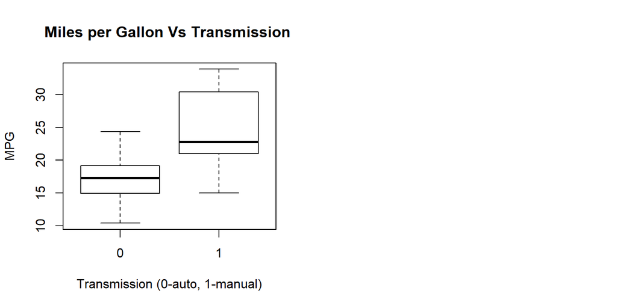

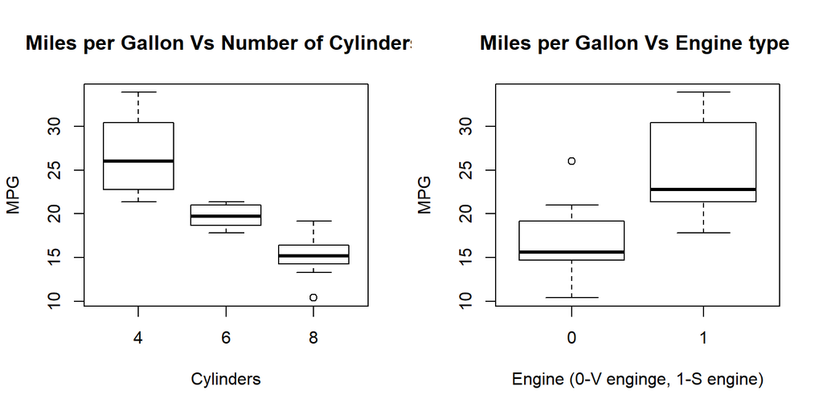

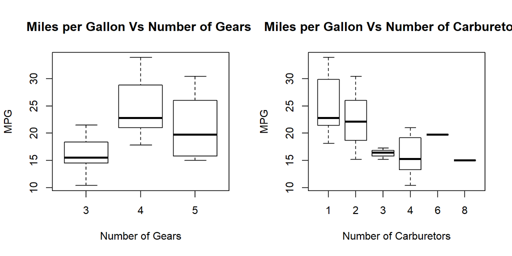

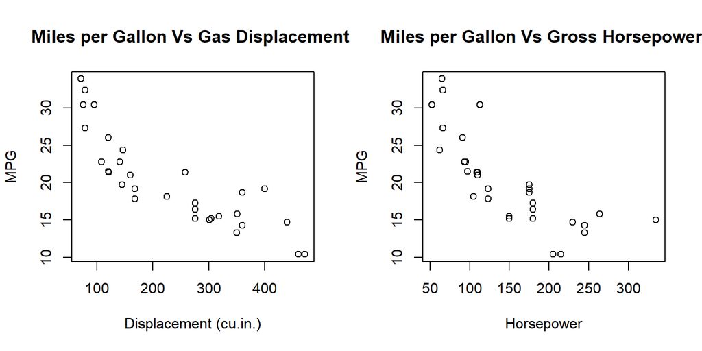

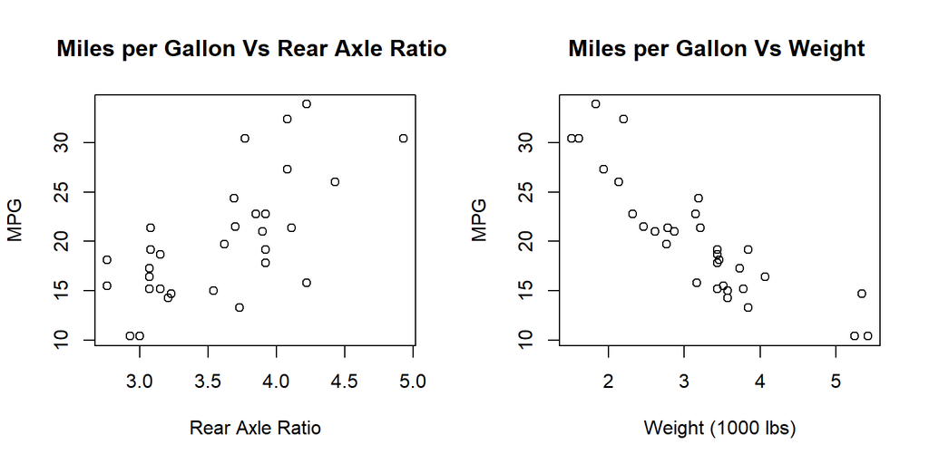

## A2 - Residuals plot

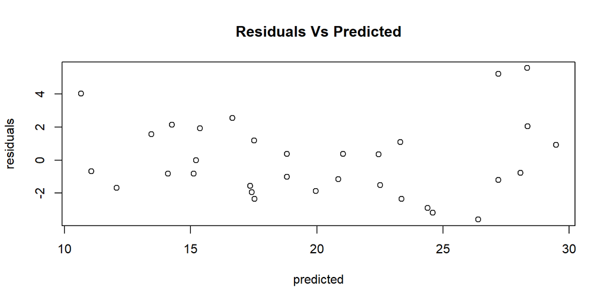